# hw-02

Zihan Kong(s2778821)

2026-10-30

```r
strava_runs <- read_csv("data/strava_runs.csv")
data_5k_10k <- strava_runs %>%
  mutate(
    event = case_when(
      distance..m. > 4998 & distance..m. < 5015  ~ "5k",
      distance..m. > 9998 & distance..m. < 10015 ~ "10k",
      TRUE ~ NA_character_
    )
  ) %>%
  filter(!is.na(event))
```

## Exercise 1

When you fill the missing part, remove the # symbol before running the code chunk and eval=FALSE

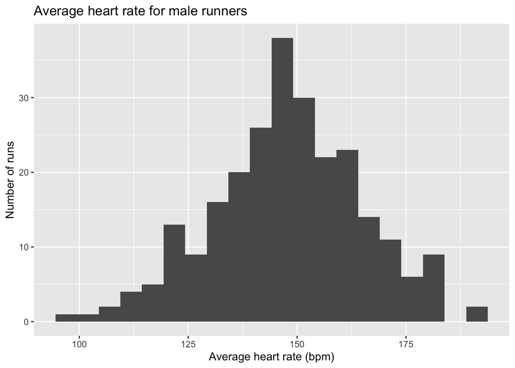

```r
data_5k_10k %>%
  filter(gender == "M") %>%
  filter(!is.na(average.heart.rate..bpm.)) %>%
  ggplot(aes(x = average.heart.rate..bpm.)) +
  geom_histogram(bins = 20) +
  labs(
    title = "Average heart rate for male runners",
    x = "Average heart rate (bpm)",
    y = "Number of runs"
  )
```

```r
data_5k_10k %>%
  filter(gender == "M") %>%
  summarise(
    n = sum(!is.na(average.heart.rate..bpm.)),
    mean_bpm = mean(average.heart.rate..bpm., na.rm = TRUE),
    median_bpm = median(average.heart.rate..bpm., na.rm = TRUE),
    sd_bpm = sd(average.heart.rate..bpm., na.rm = TRUE)
  )
```

```
## # A tibble: 1 × 4
##       n mean_bpm median_bpm sd_bpm
##   <int>    <dbl>      <dbl>  <dbl>
## 1   252     148.       148.   17.2
```

The histogram is approximately unimodal and bell-shaped, with a main peak around 145–150 bpm. The mean (147.94 bpm) and median (147.90 bpm) are almost identical, supporting an approximately symmetric distribution. The standard deviation is 17.22 bpm. There is no clear evidence of separate clusters in this histogram. These statistics are based on 252 runs with non-missing heart rate measurements.

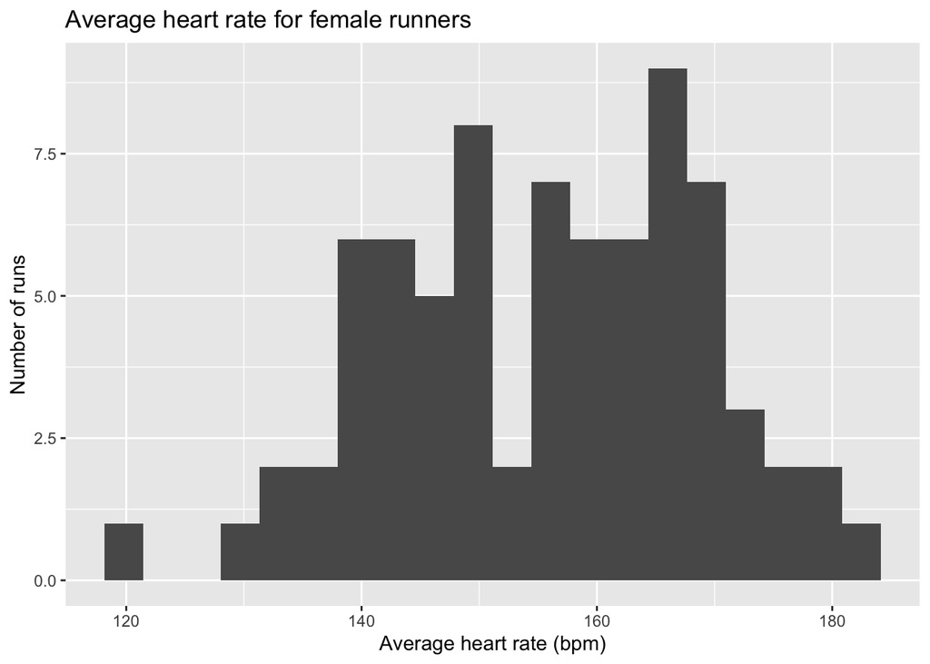

```r
# Write your code for Ex1b here
data_5k_10k %>%
  filter(gender == "F") %>%
  filter(!is.na(average.heart.rate..bpm.)) %>%
  ggplot(aes(x = average.heart.rate..bpm.)) +
  geom_histogram(bins = 20) +
  labs(
    title = "Average heart rate for female runners",
    x = "Average heart rate (bpm)",
    y = "Number of runs"
  )
```

```r
data_5k_10k %>%
  filter(gender == "F") %>%
  summarise(
    n = sum(!is.na(average.heart.rate..bpm.)),
    mean_bpm = mean(average.heart.rate..bpm., na.rm = TRUE),
    median_bpm = median(average.heart.rate..bpm., na.rm = TRUE),
    sd_bpm = sd(average.heart.rate..bpm., na.rm = TRUE)
  )
```

```
## # A tibble: 1 × 4
##       n mean_bpm median_bpm sd_bpm
##   <int>    <dbl>      <dbl>  <dbl>
## 1    76     156.       157.   13.2
```

The female histogram has several peaks and is less smooth than the male histogram. Female runs have a higher mean heart rate (155.68 bpm) than male runs (147.94 bpm). The standard deviation is smaller for females (13.22 versus 17.22 bpm), so their heart rates are less spread out. However, the two distributions overlap.